# ITMD514_05 Lab 1

#### (a) Calculate the average, variance, and standard deviation of the speed and distance variables of the cars dataset, and save them in appropriately named variables.

```r
# average distance of cars
average_dist <- mean(dist_cars)
print(average_dist)
```

```
## [1] 42.98
```

```r
# average speed of cars
average_speed <- mean(speed_cars)
print(average_speed)
```

```
## [1] 15.4
```

```r
# variance distance of cars
variance_dist <- var(dist_cars)
print(variance_dist)
```

```
## [1] 664.0608
```

```r
# variance speed of cars
variance_speed <- var(speed_cars)
print(variance_speed)
```

```
## [1] 27.95918
```

```r
# standard deviation of distance of cars
standarddev_dist <- sd(dist_cars)
print(standarddev_dist)
```

```
## [1] 25.76938
```

```r
# standard deviation of speed of cars
standarddev_speed <- sd(speed_cars)
print(standarddev_speed)
```

```
## [1] 5.287644
```

We will produce a histogram of stopping distance using the `qplot` function. (Note that this method is deprecated, but we will use it in this first assignment due to its simplicity)

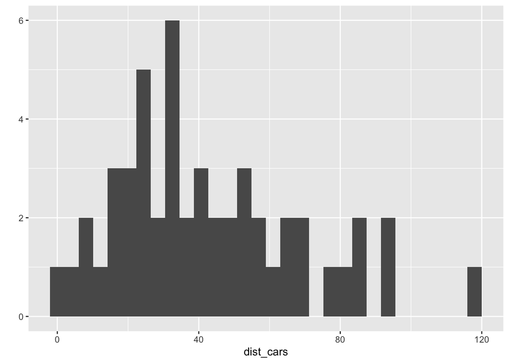

```r
qplot(dist_cars) # Histogram of stopping distance
```

The `qplot(x,y,...)` function can also be used to plot a vector `y` against a vector `x`. As always, type `?qplot` into the Console to learn more about the basic qplot function.

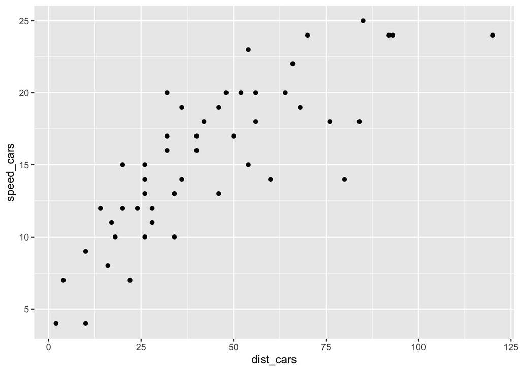

```r
qplot(dist_cars, speed_cars)
```